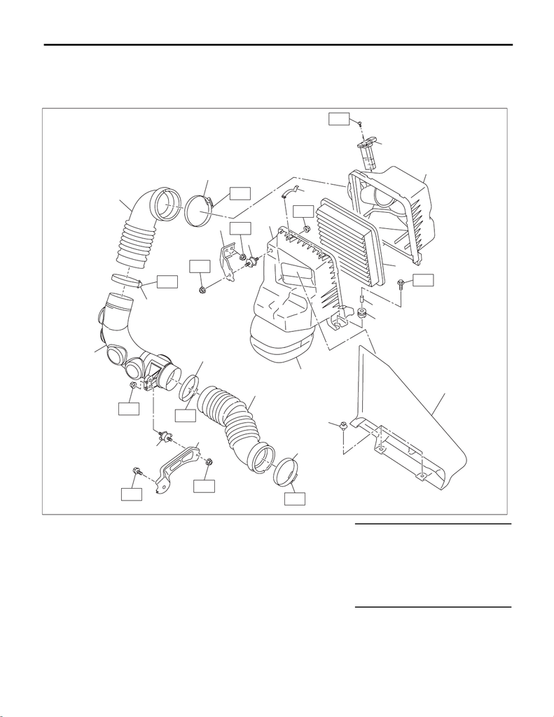

General Description

INTAKE (INDUCTION)

1. General Description

A: COMPONENT

1. AIR CLEANER

(1) Mass air flow and intake air tem-

perature sensor

(10) Resonator chamber Tightening torque: N·m (kgf-m, ft-lb)

(2) Air cleaner case (rear) (11) Air intake duct T1: 1 (0.1, 0.7)

(3) Clip (12) Clip T2: 2.5 (0.3, 1.8)

(4) Air cleaner element (13) Clamp T3: 6 (0.6, 4.4)

(5) Air cleaner case (front) (14) Air intake boot A T4: 7.5 (0.8, 5.5)

(6) Cushion (15) Turbo duct T5: 18 (1.8, 13.3)

(7) Spacer (16) Air intake boot B

(8) Cushion (17) Cushion

(9) Air cleaner case bracket (18) Duct bracket

IN-03533

(13)

(13)

(1)

(3)

(6)

(5)

(4)

(7)

(8)

(14)

(15)

(17)

(18)

(16)

(13)

(2)

(10)

T5

T2

T4

T2

T2

T4

T2

T4

T3

T1

(13)

T4

T4

(9)

(11)

(14)

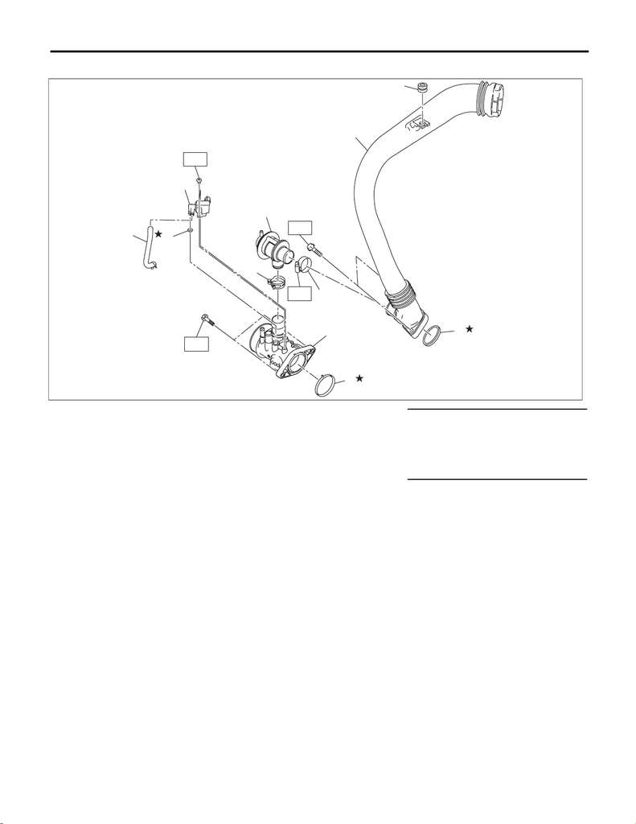

General Description

INTAKE (INDUCTION)

2. INTAKE DUCT

(1) Intake duct No. 1 (7) Air by-pass valve Tightening torque: N·m (kgf-m, ft-lb)

(2) O-ring (8) Clamp T1: 2.8 (0.3, 2.1)

(3) O-ring (9) O-ring T2: 3 (0.3, 2.2)

(4) Wastegate control solenoid valve (10) Intake duct No. 2 T3: 6.4 (0.7, 4.7)

(5) Vacuum control hose (11) Cushion T4: 16 (1.6, 11.8)

(6) Clip

IN-03210

(1)

(10)

(6)

(3)

(11)

(8)

(7)

(5)

(4)

(9)

(2)

T1

T3

T2

T4

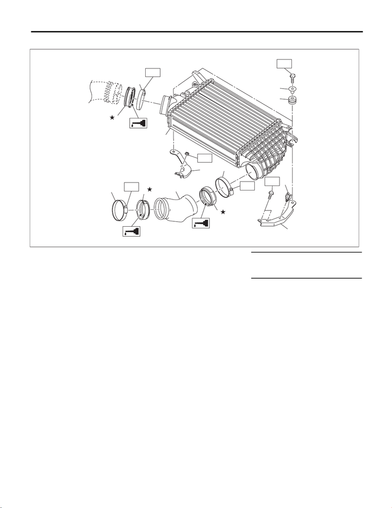

General Description

INTAKE (INDUCTION)

3. INTAKE DUCT AND INTERCOOLER

(1) Clamp (6) Intercooler Tightening torque: N·m (kgf-m, ft-lb)

(2) Insulator (7) Cushion T1: 3 (0.3, 2.2)

(3) Intake duct No. 3 (8) Spacer T2: 16 (1.6, 11.8)

(4) Intercooler stay LH (9) Insulator

(5) Intercooler stay RH (10) Clip

IN-03400

(8)

(7)

(9)

(1)

(4)

(1)

(3)

(1)

(2)

(2)

(5)

(6)

T1

T2

T2

T2

T1

T1

(10)

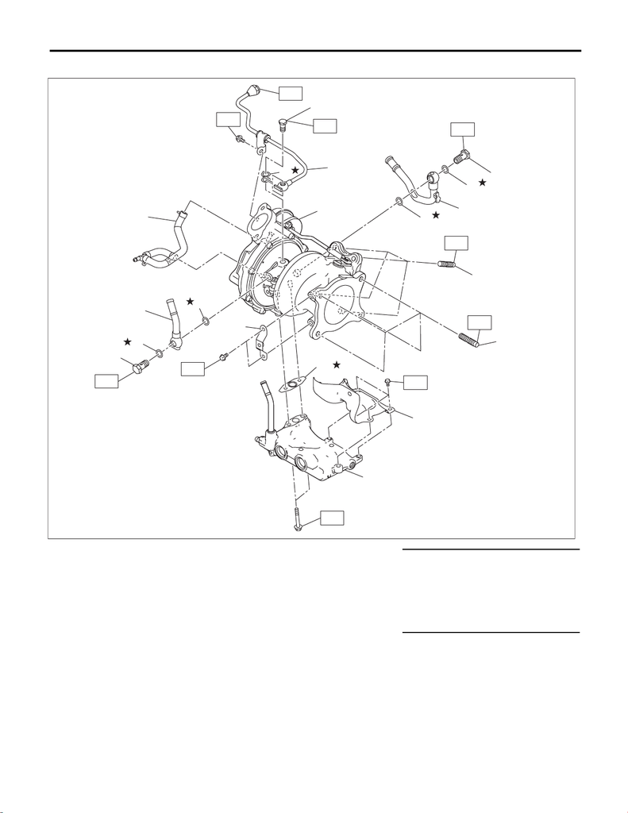

General Description

INTAKE (INDUCTION)

4. TURBOCHARGER

(1) Turbocharger (8) Turbocharger pipe A Tightening torque: N·m (kgf-m, ft-lb)

(2) Union screw pipe ASSY (9) Turbocharger pipe B T1: 6.4 (0.7, 4.7)

(3) Union bolt (10) Stud bolt T2: 10.5 (1.1, 7.7)

(4) Gasket (11) Exhaust stay T3: 14.7 (1.5, 10.8)

(5) Air control hose ASSY (12) Exhaust cover T4: 16 (1.6, 11.8)

(6) Gasket (13) Gasket T5: 31.5 (3.2, 23.2)

(7) Union bolt (14) Oil catch tank

IN-03639

(6)

(7)

(9)

(12)

(14)

(6)

(1)

(4)

(2)

(10)

(10)

(3)

(5)

(8)

(11)

(7)

(6)

(6)

T5

T1

T2

T1

T3

T3

T5

T1

T4

T4

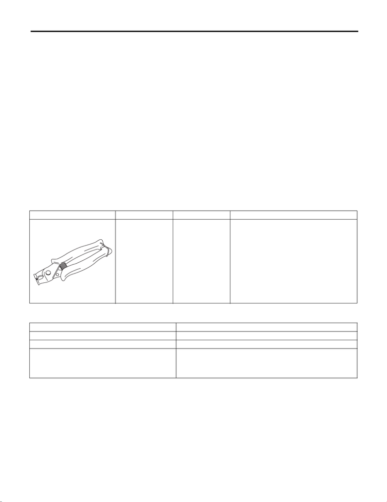

General Description

INTAKE (INDUCTION)

B: CAUTION

• Prior to starting work, pay special attention to the following:

1. Always wear work clothes, a work cap, and protective shoes. Additionally, wear a helmet, protective

goggles, etc. if necessary.

2. Protect the vehicle using a seat cover, fender cover, etc.

3. Prepare the service tools, clean cloth, containers to catch grease and oil, etc.

• Vehicle components are extremely hot immediately after driving. Be wary of receiving burns from heated

parts.

• When performing a repair, identify the cause of trouble and avoid unnecessary removal, disassembly and

replacement.

• Before disconnecting connectors of sensors or units, be sure to disconnect the ground cable from battery.

• Always use the jack-up point when the shop jacks or rigid racks are used to support the vehicle.

• Remove contamination including dirt and corrosion before removal, installation, disassembly or assembly.

• Keep the removed parts in order and protect them from dust and dirt.

• All removed parts, if to be reused, should be reinstalled in the original positions with attention to the correct

directions, etc.

• Bolts, nuts and washers should be replaced with new parts as required.

• Be sure to tighten the fasteners including bolts and nuts to the specified torque.

C: PREPARATION TOOL

1. SPECIAL TOOL

2. GENERAL TOOL

ILLUSTRATION TOOL NUMBER DESCRIPTION REMARKS

18353AA000 CLAMP PLIERS • Used for removing and installing the PCV hose

assembly.

• This tool is made by the French company

CAILLAU. (code) 54.0.000.205

To make it easier to obtain, it has been provided

with a tool number.

TOOL NAME REMARKS

TORX

®

socket E10 Used for disassembling and assembling the turbocharger.

Mighty Vac Used for checking waste gate actuator and air by-pass valve.

Urethane sheet

Width × Height × Thickness

Approx. 300 mm × approx. 200 mm × approx. 10 mm

(Approx. 11.81 in × approx. 7.87 in × approx. 0.39 in)

Used for removing and installing intercooler. (MT model)